# Loan Prediction

In this model we will predict the eligibilty of a person for loan.

# Importing required libraries

```python
import pandas as pd
import numpy as np
import matplotlib.pyplot as plt
import seaborn as sns
%matplotlib inline
```

# Importing our training data

```python
train=pd.read_csv('train.csv')
```

```python
train.head()
```

|  | Loan_ID | Gender | Married | Dependents | Education | Self_Employed | ApplicantIncome | CoapplicantIncome | LoanAmount | Loan_Amount_Term | Credit_History | Property_Area | Loan_Status |
| --- | --- | --- | --- | --- | --- | --- | --- | --- | --- | --- | --- | --- | --- |
| 0 | LP001002 | Male | No | 0 | Graduate | No | 5849 | 0.0 | NaN | 360.0 | 1.0 | Urban | Y |
| 1 | LP001003 | Male | Yes | 1 | Graduate | No | 4583 | 1508.0 | 128.0 | 360.0 | 1.0 | Rural | N |
| 2 | LP001005 | Male | Yes | 0 | Graduate | Yes | 3000 | 0.0 | 66.0 | 360.0 | 1.0 | Urban | Y |
| 3 | LP001006 | Male | Yes | 0 | Not Graduate | No | 2583 | 2358.0 | 120.0 | 360.0 | 1.0 | Urban | Y |
| 4 | LP001008 | Male | No | 0 | Graduate | No | 6000 | 0.0 | 141.0 | 360.0 | 1.0 | Urban | Y |

# Checking for null values

```python
train.isnull().sum()
```

```
Loan_ID               0
Gender               13
Married               3
Dependents           15
Education             0
Self_Employed        32
ApplicantIncome       0
CoapplicantIncome     0
LoanAmount           22
Loan_Amount_Term     14
Credit_History       50
Property_Area         0
Loan_Status           0
dtype: int64
```

We can see that we have quite a lot null values.Therefore, first we will determine the required features and then deal with the null values.

# Finding relation between different features and our target variable

Relation between gender and loan status.

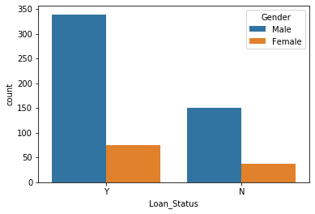

```python
sns.countplot(x='Loan_Status',hue='Gender',data=train)
```

We see that the gender of the applicant does not play a significant role in the process.

Relation between relationship status and loan status.

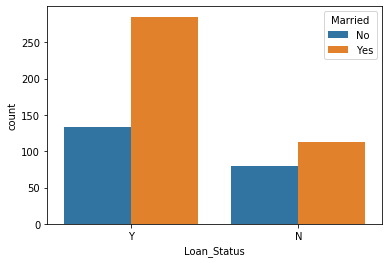

```python
sns.countplot(x='Loan_Status',hue='Married',data=train)
```

We see that married people have a greater chance of getting the loan.

Relation between dependents and loan status.

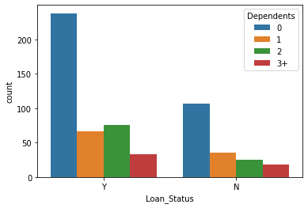

```python
sns.countplot(x='Loan_Status',hue='Dependents',data=train)
```

Relation between education level of the applicant and loan status.

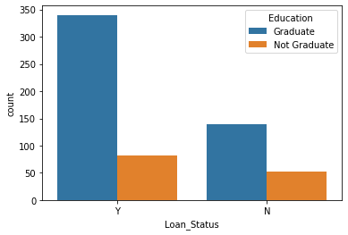

```python
sns.countplot(x='Loan_Status',hue='Education',data=train)
```

Graduates have more chances of getting the loan.

Relation between the applicant's employment type and loan status.

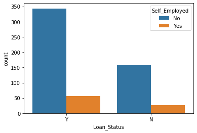

```python
sns.countplot(x='Loan_Status',hue='Self_Employed',data=train)
```

Relation between loan amount term and loan status.

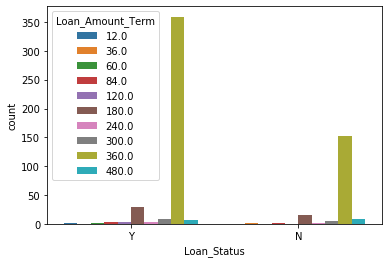

```python
sns.countplot(x='Loan_Status',hue='Loan_Amount_Term',data=train)
```

Relation between credit history and loan status.

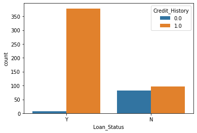

```python
sns.countplot(x='Loan_Status',hue='Credit_History',data=train)
```

Credit history play a significant role in the process.

Relation between property area and loan status.

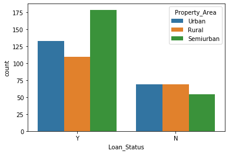

```python
sns.countplot(x='Loan_Status',hue='Property_Area',data=train)
```

# Filtering out required features

```python
train.drop(['Gender','CoapplicantIncome','Loan_Amount_Term','Property_Area'],axis=1,inplace=True);
```

```python
train.head()
```

|  | Loan_ID | Married | Dependents | Education | Self_Employed | ApplicantIncome | LoanAmount | Credit_History | Loan_Status |
| --- | --- | --- | --- | --- | --- | --- | --- | --- | --- |
| 0 | LP001002 | No | 0 | Graduate | No | 5849 | NaN | 1.0 | Y |
| 1 | LP001003 | Yes | 1 | Graduate | No | 4583 | 128.0 | 1.0 | N |
| 2 | LP001005 | Yes | 0 | Graduate | Yes | 3000 | 66.0 | 1.0 | Y |
| 3 | LP001006 | Yes | 0 | Not Graduate | No | 2583 | 120.0 | 1.0 | Y |
| 4 | LP001008 | No | 0 | Graduate | No | 6000 | 141.0 | 1.0 | Y |

# Converting categorical data into indicator data

```python
married=pd.get_dummies(train['Married'],drop_first=True)
education=pd.get_dummies(train['Education'],drop_first=True)
self_employed=pd.get_dummies(train['Self_Employed'],drop_first=True)
```

```python
train=pd.concat([train,married,education],axis=1)
train.head()
```

|  | Loan_ID | Married | Dependents | Education | Self_Employed | ApplicantIncome | LoanAmount | Credit_History | Loan_Status | Yes | Not Graduate |
| --- | --- | --- | --- | --- | --- | --- | --- | --- | --- | --- | --- |
| 0 | LP001002 | No | 0 | Graduate | No | 5849 | NaN | 1.0 | Y | 0 | 0 |
| 1 | LP001003 | Yes | 1 | Graduate | No | 4583 | 128.0 | 1.0 | N | 1 | 0 |
| 2 | LP001005 | Yes | 0 | Graduate | Yes | 3000 | 66.0 | 1.0 | Y | 1 | 0 |
| 3 | LP001006 | Yes | 0 | Not Graduate | No | 2583 | 120.0 | 1.0 | Y | 1 | 1 |
| 4 | LP001008 | No | 0 | Graduate | No | 6000 | 141.0 | 1.0 | Y | 0 | 0 |

```python
train.rename(columns={'Yes':'married'},inplace=True)
train.head()
```

|  | Loan_ID | Married | Dependents | Education | Self_Employed | ApplicantIncome | LoanAmount | Credit_History | Loan_Status | married | Not Graduate |
| --- | --- | --- | --- | --- | --- | --- | --- | --- | --- | --- | --- |
| 0 | LP001002 | No | 0 | Graduate | No | 5849 | NaN | 1.0 | Y | 0 | 0 |
| 1 | LP001003 | Yes | 1 | Graduate | No | 4583 | 128.0 | 1.0 | N | 1 | 0 |
| 2 | LP001005 | Yes | 0 | Graduate | Yes | 3000 | 66.0 | 1.0 | Y | 1 | 0 |
| 3 | LP001006 | Yes | 0 | Not Graduate | No | 2583 | 120.0 | 1.0 | Y | 1 | 1 |
| 4 | LP001008 | No | 0 | Graduate | No | 6000 | 141.0 | 1.0 | Y | 0 | 0 |

```python
train=pd.concat([train,self_employed],axis=1)
train.head()
```

|  | Loan_ID | Married | Dependents | Education | Self_Employed | ApplicantIncome | LoanAmount | Credit_History | Loan_Status | married | Not Graduate | Yes |
| --- | --- | --- | --- | --- | --- | --- | --- | --- | --- | --- | --- | --- |
| 0 | LP001002 | No | 0 | Graduate | No | 5849 | NaN | 1.0 | Y | 0 | 0 | 0 |
| 1 | LP001003 | Yes | 1 | Graduate | No | 4583 | 128.0 | 1.0 | N | 1 | 0 | 0 |
| 2 | LP001005 | Yes | 0 | Graduate | Yes | 3000 | 66.0 | 1.0 | Y | 1 | 0 | 1 |
| 3 | LP001006 | Yes | 0 | Not Graduate | No | 2583 | 120.0 | 1.0 | Y | 1 | 1 | 0 |
| 4 | LP001008 | No | 0 | Graduate | No | 6000 | 141.0 | 1.0 | Y | 0 | 0 | 0 |

```python
train.rename(columns={'Yes':'self_employed'},inplace=True)
train.head()
```

|  | Loan_ID | Married | Dependents | Education | Self_Employed | ApplicantIncome | LoanAmount | Credit_History | Loan_Status | married | Not Graduate | self_employed |
| --- | --- | --- | --- | --- | --- | --- | --- | --- | --- | --- | --- | --- |
| 0 | LP001002 | No | 0 | Graduate | No | 5849 | NaN | 1.0 | Y | 0 | 0 | 0 |
| 1 | LP001003 | Yes | 1 | Graduate | No | 4583 | 128.0 | 1.0 | N | 1 | 0 | 0 |
| 2 | LP001005 | Yes | 0 | Graduate | Yes | 3000 | 66.0 | 1.0 | Y | 1 | 0 | 1 |
| 3 | LP001006 | Yes | 0 | Not Graduate | No | 2583 | 120.0 | 1.0 | Y | 1 | 1 | 0 |
| 4 | LP001008 | No | 0 | Graduate | No | 6000 | 141.0 | 1.0 | Y | 0 | 0 | 0 |

```python
train.drop(['Married','Education','Self_Employed'],axis=1,inplace=True)
```

```python
train.head()
```

|  | Loan_ID | Dependents | ApplicantIncome | LoanAmount | Credit_History | Loan_Status | married | Not Graduate | self_employed |
| --- | --- | --- | --- | --- | --- | --- | --- | --- | --- |
| 0 | LP001002 | 0 | 5849 | NaN | 1.0 | Y | 0 | 0 | 0 |
| 1 | LP001003 | 1 | 4583 | 128.0 | 1.0 | N | 1 | 0 | 0 |
| 2 | LP001005 | 0 | 3000 | 66.0 | 1.0 | Y | 1 | 0 | 1 |
| 3 | LP001006 | 0 | 2583 | 120.0 | 1.0 | Y | 1 | 1 | 0 |
| 4 | LP001008 | 0 | 6000 | 141.0 | 1.0 | Y | 0 | 0 | 0 |

```python
train.isnull().sum()
```

```
Loan_ID             0
Dependents         15
ApplicantIncome     0
LoanAmount         22
Credit_History     50
Loan_Status         0
married             0
Not Graduate        0
self_employed       0
dtype: int64
```

We see that dependents is also categorical data.Therefore,we need to convert it to indicator data.

```python
dependents=pd.get_dummies(train['Dependents'],drop_first=True)
```

```python
train=pd.concat([train,dependents],axis=1)
train.head()
```

|  | Loan_ID | Dependents | ApplicantIncome | LoanAmount | Credit_History | Loan_Status | married | Not Graduate | self_employed | 1 | 2 | 3+ |
| --- | --- | --- | --- | --- | --- | --- | --- | --- | --- | --- | --- | --- |
| 0 | LP001002 | 0 | 5849 | NaN | 1.0 | Y | 0 | 0 | 0 | 0 | 0 | 0 |
| 1 | LP001003 | 1 | 4583 | 128.0 | 1.0 | N | 1 | 0 | 0 | 1 | 0 | 0 |
| 2 | LP001005 | 0 | 3000 | 66.0 | 1.0 | Y | 1 | 0 | 1 | 0 | 0 | 0 |
| 3 | LP001006 | 0 | 2583 | 120.0 | 1.0 | Y | 1 | 1 | 0 | 0 | 0 | 0 |
| 4 | LP001008 | 0 | 6000 | 141.0 | 1.0 | Y | 0 | 0 | 0 | 0 | 0 | 0 |

```python
train.drop('Dependents',axis=1,inplace=True)
train.head()
```

|  | Loan_ID | ApplicantIncome | LoanAmount | Credit_History | Loan_Status | married | Not Graduate | self_employed | 1 | 2 | 3+ |
| --- | --- | --- | --- | --- | --- | --- | --- | --- | --- | --- | --- |
| 0 | LP001002 | 5849 | NaN | 1.0 | Y | 0 | 0 | 0 | 0 | 0 | 0 |
| 1 | LP001003 | 4583 | 128.0 | 1.0 | N | 1 | 0 | 0 | 1 | 0 | 0 |
| 2 | LP001005 | 3000 | 66.0 | 1.0 | Y | 1 | 0 | 1 | 0 | 0 | 0 |
| 3 | LP001006 | 2583 | 120.0 | 1.0 | Y | 1 | 1 | 0 | 0 | 0 | 0 |
| 4 | LP001008 | 6000 | 141.0 | 1.0 | Y | 0 | 0 | 0 | 0 | 0 | 0 |

# Checking for null values

```python
train.isnull().sum()
```

```
Loan_ID             0
ApplicantIncome     0
LoanAmount         22
Credit_History     50
Loan_Status         0
married             0
Not Graduate        0
self_employed       0
1                   0
2                   0
3+                  0
dtype: int64
```

# Filling up null values

```python
def fill_loan(cols):
    amount=cols[0]

    if pd.isnull(amount):
        return train['LoanAmount'].mean()

    return amount
```

```python
train['LoanAmount']=train[['LoanAmount']].apply(fill_loan,axis=1)
```

```python
train.isnull().sum()
```

```
Loan_ID             0
ApplicantIncome     0
LoanAmount          0
Credit_History     50
Loan_Status         0
married             0
Not Graduate        0
self_employed       0
1                   0
2                   0
3+                  0
dtype: int64
```

```python
def fill_credithistory(cols):
    credit_history=cols[0]

    if pd.isnull(credit_history):
        return 1

    return credit_history
```

```python
train['Credit_History']=train[['Credit_History']].apply(fill_credithistory,axis=1)
```

```python
train.isnull().sum()
```

```
Loan_ID            0
ApplicantIncome    0
LoanAmount         0
Credit_History     0
Loan_Status        0
married            0
Not Graduate       0
self_employed      0
1                  0
2                  0
3+                 0
dtype: int64
```

We have successfully removed all null values.

# Building model

Importing required libraries.

```python
from sklearn.tree import DecisionTreeClassifier
```

```python
classifier=DecisionTreeClassifier()
```

# Splitting our data

Separating our features and target variable.

```python
x=train.drop(['Loan_Status','Loan_ID'],axis=1)
y=train['Loan_Status']
```

Importing required libraries.

```python
from sklearn.model_selection import train_test_split
```

```python
x_train,x_test,y_train,y_test=train_test_split(x,y,test_size=0.2)
```

# Training and testing our model

```python
classifier.fit(x_train,y_train)
```

```
DecisionTreeClassifier(ccp_alpha=0.0, class_weight=None, criterion='gini',
                       max_depth=None, max_features=None, max_leaf_nodes=None,
                       min_impurity_decrease=0.0, min_impurity_split=None,
                       min_samples_leaf=1, min_samples_split=2,
                       min_weight_fraction_leaf=0.0, presort='deprecated',
                       random_state=None, splitter='best')
```

```python
y_hat=classifier.predict(x_test)
```

```python
y_hat
```

```
array(['Y', 'N', 'N', 'Y', 'Y', 'N', 'Y', 'Y', 'N', 'Y', 'Y', 'Y', 'Y',
       'Y', 'Y', 'Y', 'Y', 'Y', 'N', 'Y', 'N', 'Y', 'N', 'Y', 'Y', 'N',
       'N', 'Y', 'Y', 'N', 'Y', 'N', 'Y', 'N', 'Y', 'N', 'Y', 'N', 'Y',
       'Y', 'N', 'Y', 'Y', 'Y', 'Y', 'Y', 'Y', 'Y', 'Y', 'Y', 'N', 'Y',
       'Y', 'N', 'Y', 'Y', 'Y', 'Y', 'N', 'Y', 'N', 'N', 'N', 'Y', 'Y',
       'Y', 'N', 'N', 'Y', 'Y', 'Y', 'Y', 'Y', 'Y', 'Y', 'Y', 'Y', 'N',
       'N', 'Y', 'N', 'Y', 'N', 'N', 'Y', 'N', 'N', 'Y', 'Y', 'N', 'Y',
       'N', 'Y', 'Y', 'Y', 'N', 'N', 'N', 'Y', 'Y', 'N', 'N', 'Y', 'Y',
       'Y', 'Y', 'N', 'N', 'N', 'Y', 'Y', 'N', 'Y', 'Y', 'N', 'Y', 'N',
       'Y', 'Y', 'Y', 'Y', 'Y', 'N'], dtype=object)
```

# Finding out accuracy score

```python
from sklearn.metrics import accuracy_score
```

```python
accuracy=accuracy_score(y_test,y_hat)
accuracy
```

```
0.7073170731707317
```

# Importing testing data

```python
test=pd.read_csv('test.csv')
```

```python
test.head()
```

|  | Loan_ID | Gender | Married | Dependents | Education | Self_Employed | ApplicantIncome | CoapplicantIncome | LoanAmount | Loan_Amount_Term | Credit_History | Property_Area |
| --- | --- | --- | --- | --- | --- | --- | --- | --- | --- | --- | --- | --- |
| 0 | LP001015 | Male | Yes | 0 | Graduate | No | 5720 | 0 | 110.0 | 360.0 | 1.0 | Urban |
| 1 | LP001022 | Male | Yes | 1 | Graduate | No | 3076 | 1500 | 126.0 | 360.0 | 1.0 | Urban |
| 2 | LP001031 | Male | Yes | 2 | Graduate | No | 5000 | 1800 | 208.0 | 360.0 | 1.0 | Urban |
| 3 | LP001035 | Male | Yes | 2 | Graduate | No | 2340 | 2546 | 100.0 | 360.0 | NaN | Urban |
| 4 | LP001051 | Male | No | 0 | Not Graduate | No | 3276 | 0 | 78.0 | 360.0 | 1.0 | Urban |

# Modifying testing data

```python
test.drop(['Gender','CoapplicantIncome','Loan_Amount_Term','Property_Area'],axis=1,inplace=True);
```

```python
married=pd.get_dummies(test['Married'],drop_first=True)
education=pd.get_dummies(test['Education'],drop_first=True)
self_employed=pd.get_dummies(test['Self_Employed'],drop_first=True)
```

```python
test=pd.concat([test,married,education],axis=1)
```

```python
test.rename(columns={'Yes':'married'},inplace=True)
test.head()
```

|  | Loan_ID | Married | Dependents | Education | Self_Employed | ApplicantIncome | LoanAmount | Credit_History | married | Not Graduate |
| --- | --- | --- | --- | --- | --- | --- | --- | --- | --- | --- |
| 0 | LP001015 | Yes | 0 | Graduate | No | 5720 | 110.0 | 1.0 | 1 | 0 |
| 1 | LP001022 | Yes | 1 | Graduate | No | 3076 | 126.0 | 1.0 | 1 | 0 |
| 2 | LP001031 | Yes | 2 | Graduate | No | 5000 | 208.0 | 1.0 | 1 | 0 |
| 3 | LP001035 | Yes | 2 | Graduate | No | 2340 | 100.0 | NaN | 1 | 0 |
| 4 | LP001051 | No | 0 | Not Graduate | No | 3276 | 78.0 | 1.0 | 0 | 1 |

```python
test=pd.concat([test,self_employed],axis=1)
```

```python
test.rename(columns={'Yes':'self_employed'},inplace=True)
test.head()
```

|  | Loan_ID | Married | Dependents | Education | Self_Employed | ApplicantIncome | LoanAmount | Credit_History | married | Not Graduate | self_employed |
| --- | --- | --- | --- | --- | --- | --- | --- | --- | --- | --- | --- |
| 0 | LP001015 | Yes | 0 | Graduate | No | 5720 | 110.0 | 1.0 | 1 | 0 | 0 |
| 1 | LP001022 | Yes | 1 | Graduate | No | 3076 | 126.0 | 1.0 | 1 | 0 | 0 |
| 2 | LP001031 | Yes | 2 | Graduate | No | 5000 | 208.0 | 1.0 | 1 | 0 | 0 |
| 3 | LP001035 | Yes | 2 | Graduate | No | 2340 | 100.0 | NaN | 1 | 0 | 0 |
| 4 | LP001051 | No | 0 | Not Graduate | No | 3276 | 78.0 | 1.0 | 0 | 1 | 0 |

```python
test.drop(['Married','Education','Self_Employed'],axis=1,inplace=True)
```

```python
dependents=pd.get_dummies(test['Dependents'],drop_first=True)
```

```python
test=pd.concat([test,dependents],axis=1)
```

```python
test.drop('Dependents',axis=1,inplace=True)
test.head()
```

|  | Loan_ID | ApplicantIncome | LoanAmount | Credit_History | married | Not Graduate | self_employed | 1 | 2 | 3+ |
| --- | --- | --- | --- | --- | --- | --- | --- | --- | --- | --- |
| 0 | LP001015 | 5720 | 110.0 | 1.0 | 1 | 0 | 0 | 0 | 0 | 0 |
| 1 | LP001022 | 3076 | 126.0 | 1.0 | 1 | 0 | 0 | 1 | 0 | 0 |
| 2 | LP001031 | 5000 | 208.0 | 1.0 | 1 | 0 | 0 | 0 | 1 | 0 |
| 3 | LP001035 | 2340 | 100.0 | NaN | 1 | 0 | 0 | 0 | 1 | 0 |
| 4 | LP001051 | 3276 | 78.0 | 1.0 | 0 | 1 | 0 | 0 | 0 | 0 |

```python
test.isnull().sum()
```

```
Loan_ID             0
ApplicantIncome     0
LoanAmount          5
Credit_History     29
married             0
Not Graduate        0
self_employed       0
1                   0
2                   0
3+                  0
dtype: int64
```

```python
def fill_loan_test(cols):
    amount=cols[0]

    if pd.isnull(amount):
        return test['LoanAmount'].mean()

    return amount
```

```python
test['LoanAmount']=test[['LoanAmount']].apply(fill_loan_test,axis=1)
```

```python
test['Credit_History']=test[['Credit_History']].apply(fill_credithistory,axis=1)
```

```python
test.isnull().sum()
```

```
Loan_ID            0
ApplicantIncome    0
LoanAmount         0
Credit_History     0
married            0
Not Graduate       0
self_employed      0
1                  0
2                  0
3+                 0
dtype: int64
```

# Making predictions on testing data

```python
x=test.drop(['Loan_ID'],axis=1)
```

```python
predictions=classifier.predict(x)
```

```python
predictions
```

```
array(['Y', 'Y', 'Y', 'Y', 'Y', 'Y', 'Y', 'N', 'Y', 'Y', 'N', 'Y', 'Y',
       'N', 'Y', 'Y', 'Y', 'Y', 'N', 'N', 'Y', 'N', 'Y', 'Y', 'Y', 'Y',
       'Y', 'N', 'N', 'Y', 'Y', 'Y', 'Y', 'Y', 'Y', 'N', 'Y', 'Y', 'Y',
       'Y', 'Y', 'Y', 'Y', 'Y', 'Y', 'Y', 'N', 'Y', 'Y', 'Y', 'Y', 'Y',
       'Y', 'Y', 'Y', 'Y', 'Y', 'Y', 'N', 'Y', 'N', 'Y', 'Y', 'N', 'Y',
       'Y', 'N', 'Y', 'Y', 'N', 'Y', 'Y', 'N', 'Y', 'N', 'N', 'Y', 'N',
       'Y', 'Y', 'Y', 'Y', 'N', 'N', 'Y', 'Y', 'N', 'Y', 'Y', 'Y', 'Y',
       'Y', 'N', 'Y', 'N', 'N', 'Y', 'Y', 'Y', 'Y', 'Y', 'N', 'Y', 'Y',
       'Y', 'Y', 'N', 'Y', 'Y', 'Y', 'Y', 'N', 'N', 'Y', 'Y', 'N', 'N',
       'N', 'N', 'Y', 'N', 'Y', 'N', 'N', 'N', 'Y', 'N', 'Y', 'N', 'Y',
       'Y', 'N', 'Y', 'N', 'Y', 'Y', 'Y', 'Y', 'Y', 'Y', 'N', 'Y', 'N',
       'Y', 'Y', 'Y', 'Y', 'N', 'Y', 'Y', 'Y', 'Y', 'N', 'Y', 'Y', 'N',
       'Y', 'Y', 'N', 'Y', 'Y', 'N', 'Y', 'Y', 'Y', 'Y', 'N', 'N', 'N',
       'N', 'Y', 'Y', 'Y', 'N', 'Y', 'Y', 'Y', 'Y', 'Y', 'Y', 'Y', 'Y',
       'N', 'N', 'Y', 'Y', 'Y', 'Y', 'Y', 'Y', 'N', 'Y', 'N', 'N', 'Y',
       'Y', 'N', 'Y', 'Y', 'Y', 'Y', 'Y', 'Y', 'Y', 'N', 'Y', 'Y', 'Y',
       'N', 'Y', 'Y', 'N', 'N', 'Y', 'Y', 'Y', 'Y', 'Y', 'Y', 'Y', 'Y',
       'Y', 'Y', 'Y', 'N', 'Y', 'Y', 'Y', 'Y', 'N', 'Y', 'Y', 'Y', 'N',
       'Y', 'N', 'N', 'Y', 'N', 'Y', 'Y', 'N', 'Y', 'Y', 'Y', 'N', 'Y',
       'Y', 'N', 'Y', 'N', 'N', 'Y', 'Y', 'Y', 'N', 'Y', 'Y', 'Y', 'Y',
       'N', 'Y', 'N', 'Y', 'Y', 'N', 'N', 'Y', 'N', 'N', 'Y', 'Y', 'N',
       'Y', 'N', 'Y', 'Y', 'Y', 'N', 'Y', 'Y', 'Y', 'Y', 'N', 'Y', 'N',
       'Y', 'Y', 'Y', 'Y', 'N', 'Y', 'Y', 'N', 'Y', 'Y', 'Y', 'Y', 'Y',
       'Y', 'Y', 'N', 'Y', 'N', 'Y', 'Y', 'N', 'Y', 'Y', 'Y', 'N', 'N',
       'Y', 'Y', 'Y', 'Y', 'Y', 'N', 'Y', 'Y', 'Y', 'N', 'N', 'Y', 'Y',
       'N', 'Y', 'Y', 'Y', 'Y', 'Y', 'Y', 'N', 'Y', 'Y', 'N', 'Y', 'Y',
       'Y', 'Y', 'Y', 'Y', 'N', 'Y', 'Y', 'Y', 'N', 'Y', 'Y', 'Y', 'Y',
       'Y', 'Y', 'Y', 'N', 'Y', 'Y', 'Y', 'Y', 'Y', 'Y', 'Y', 'Y', 'Y',
       'Y', 'Y', 'N'], dtype=object)
```

```python
predictions.size
```

```
367
```

```python
submission=pd.DataFrame({
    'Loan_ID':test['Loan_ID'],
    'Loan_Status':predictions
})
submission.to_csv('submission.csv',index=False)
submission=pd.read_csv('submission.csv')
submission.head()
```

|  | Loan_ID | Loan_Status |
| --- | --- | --- |
| 0 | LP001015 | Y |
| 1 | LP001022 | Y |
| 2 | LP001031 | Y |
| 3 | LP001035 | Y |
| 4 | LP001051 | Y |